# Time Series - Individual Project

The Evolution of S&P 500 Dividend Levels: 1871 to Present

Vitor Reis

March 2026

[figure not shown]

# Section 1: Overall Idea

Dividends are cash payments that companies distribute to shareholders from their profits. For most of the twentieth century, dividends were the primary reason to own equities: investors expected stocks to pay a regular income, much like a bond. Today, dividend yields sit near historic lows, and many investors focus purely on capital gains.

This report investigates **how S&P 500 dividend levels have evolved over 150 years**, asking three central questions:

- How have nominal and real (inflation-adjusted) dividends grown over time?
- Has the **dividend yield** — the income return to investors — changed structurally over history?
- What do standard time series tools tell us about trend, seasonality and forecastability of dividends?

The analysis covers monthly data from **January 1871 to June 2023** (the latest point in the Shiller dataset), passing through the Second Industrial Revolution, two World Wars, the Great Depression, the dot-com bubble, the 2008 Global Financial Crisis and the Covid Pandemic.

# Section 2: Sources

| # | Dataset | Source |
| --- | --- | --- |
| 1 | S&P 500 Historical Data (Price, Dividend, Earnings, CPI) | Robert Shiller, Yale University |
| 2 | Shiller dataset download | http://www.econ.yale.edu/~shiller/data/ie_data.xls |

**Rationale for selecting this dataset:** Many sources were considered during the data exploration phase, including FRED (Federal Reserve Economic Data), Bloomberg, and S&P Dow Jones Indices. However, most of these either don’t have data before the 1920s, require paid subscriptions, or do not include CPI data for inflation adjustments. The Shiller S&P 500 dataset was selected because it is considered standard for long-run US equity research. It has been maintained continuously since the 1980s, includes inflation data (CPI) enabling real-term comparisons, provides monthly granularity back to 1871, and is freely available.

**R Libraries used:** `readxl`, `dplyr`, `ggplot2`, `lubridate`, `scales`, `forecast`, `tseries`

# Section 3: Data Acquisition and Processing

## Downloading the data

```r
# Packages needed
needed = c("readxl", "dplyr", "ggplot2", "lubridate", "scales", "forecast", "tseries")

# Only install in case is missing
for (p in needed)
  {if (!requireNamespace(p, quietly = TRUE)) install.packages(p, repos = "https://cran.r-project.org")}

# Load Libraries
library(readxl)
library(dplyr)
library(ggplot2)
library(lubridate)
library(scales)
library(forecast)
library(tseries)

# Download Shiller data
shiller_file = "ie_data.xls"
download.file(
  url      = "http://www.econ.yale.edu/~shiller/data/ie_data.xls",
  destfile = shiller_file,
  mode     = "wb")
```

## Cleaning and preparing the data

The Shiller Excel file uses a `YYYY.MM` format for dates (e.g. `1871.01` = January 1871). The dividend column reports annualised dividends per share in nominal USD.

```r
# Read: data begins on row 8; first 7 rows are headers/notes
raw_shiller = read_excel(shiller_file, sheet = "Data", skip = 7, col_names = TRUE)

# Keep only the first 6 columns and rename
raw_shiller = raw_shiller[, 1:6]
colnames(raw_shiller) = c("date_raw", "price", "dividend", "earnings", "cpi", "long_rate")

# Analyse dates and convert columns to numeric
df = raw_shiller %>%
  filter(!is.na(date_raw)) %>%
  mutate(
    date_num = suppressWarnings(as.numeric(date_raw)),
    year     = floor(date_num),
    month    = pmax(1L, pmin(12L, round((date_num - floor(date_num)) * 100))),
    date     = make_date(year, month, 1L),
    price    = as.numeric(price),
    dividend = as.numeric(dividend),
    earnings = as.numeric(earnings),
    cpi      = as.numeric(cpi)
  ) %>%
  filter(!is.na(date), !is.na(dividend), dividend > 0, year >= 1871) %>%
  arrange(date)

# Inflation-adjust all figures to the most recent month's CPI
base_cpi = tail(df$cpi, 1)

df = df %>%
  mutate(
    real_dividend = dividend * (base_cpi / cpi),
    real_price    = price    * (base_cpi / cpi),
    div_yield     = dividend / price * 100,        # percent
    payout_ratio  = ifelse(earnings > 0, dividend / earnings, NA_real_)
  )

cat("Monthly observations:", nrow(df), "\n")
```

```
## Monthly observations: 1830
```

```r
cat("Period:", format(min(df$date), "%b %Y"), "to", format(max(df$date), "%b %Y"), "\n")
```

```
## Period: Jan 1871 to Jun 2023
```

## Data preview

```r
df %>%
  select(date, price, dividend, real_dividend, div_yield) %>%
  tail(12) %>%
  mutate(
    price         = round(price, 1),
    dividend      = round(dividend, 2),
    real_dividend = round(real_dividend, 2),
    div_yield     = round(div_yield, 2)
  )
```

```
## # A tibble: 12 × 5
##    date       price dividend real_dividend div_yield
##    <date>     <dbl>    <dbl>         <dbl>     <dbl>
##  1 2022-07-01 3912.     64.4          66.4      1.65
##  2 2022-08-01 4159.     64.9          66.8      1.56
##  3 2022-09-01 3850.     65.3          67.2      1.7
##  4 2022-10-01 3726.     65.8          67.4      1.77
##  5 2022-11-01 3918.     66.4          68.0      1.69
##  6 2022-12-01 3912.     66.9          68.8      1.71
##  7 2023-01-01 3961.     67.4          68.7      1.7
##  8 2023-02-01 4080.     67.8          68.7      1.66
##  9 2023-03-01 3969.     68.2          69.0      1.72
## 10 2023-04-01 4122.     68.4          68.8      1.66
## 11 2023-05-01 4146.     68.5          68.8      1.65
## 12 2023-06-01 4345.     68.7          68.7      1.58
```

## Annual averages

For most of the analysis we use annual averages to smooth out within-year noise. We also calculate growth rates and log-dividends, which are needed later for the trend model and ARIMA.

```r
annual = df %>%
  group_by(year) %>%
  summarise(
    dividend      = mean(dividend,      na.rm = TRUE),
    real_dividend = mean(real_dividend, na.rm = TRUE),
    price         = mean(price,         na.rm = TRUE),
    div_yield     = mean(div_yield,     na.rm = TRUE),
    payout_ratio  = mean(payout_ratio,  na.rm = TRUE),
    .groups = "drop"
  ) %>%
  mutate(
    div_growth      = (dividend      / lag(dividend)      - 1) * 100, # Nominal Dividend year-over-year percentage change
    real_div_growth = (real_dividend / lag(real_dividend) - 1) * 100, # Real Dividend year-over-year percentage change
    log_div         = log(dividend)
  )
```

# Section 4: Exploratory Data Analysis

## Nominal dividend levels

The chart below shows the annualised S&P 500 dividend per share in nominal USD. Key historical crises are highlighted.

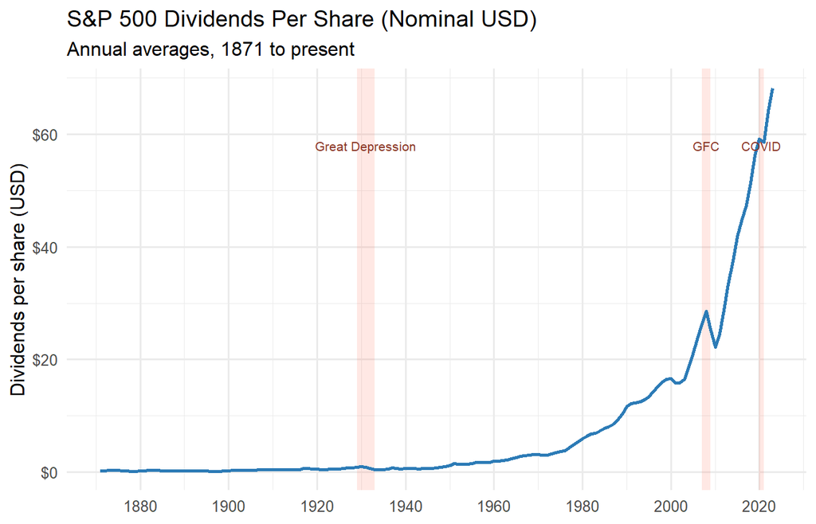

```r
# Shaded crisis periods
crises = data.frame(
  xmin = c(1929, 2007, 2020),
  xmax = c(1933, 2009, 2021),
  label = c("Great Depression", "GFC", "COVID"))

ggplot(annual, aes(x = year, y = dividend)) +
  geom_rect(data = crises,
            aes(xmin = xmin, xmax = xmax, ymin = -Inf, ymax = Inf),
            inherit.aes = FALSE,
            fill = "tomato", alpha = 0.15) +
  geom_line(colour = "#2C7BB6", linewidth = 0.9) +
  geom_text(data = crises,
            aes(x = (xmin + xmax) / 2, y = max(annual$dividend) * 0.85,
                label = label),
            size = 2.8, colour = "tomato4") +
  scale_y_continuous(labels = dollar_format()) +
  scale_x_continuous(breaks = seq(1880, 2030, 20)) +
  labs(
    title    = "S&P 500 Dividends Per Share (Nominal USD)",
    subtitle = "Annual averages, 1871 to present",
    x = NULL, y = "Dividends per share (USD)"
  ) +
  theme_minimal(base_size = 12)
```

## Real (inflation-adjusted) dividends

Adjusting for inflation shows how much buying power dividends have actually delivered over time.

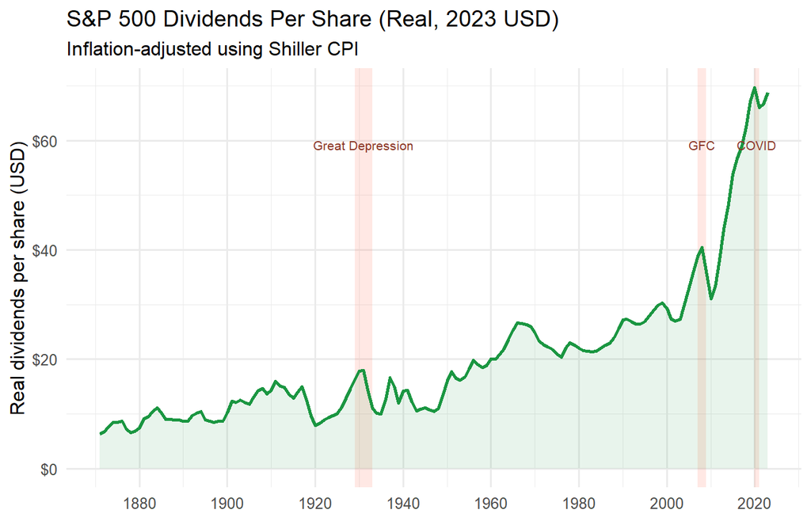

```r
# Shaded crisis bands
crises = data.frame(
  xmin = c(1929, 2007, 2020),
  xmax = c(1933, 2009, 2021),
  label = c("Great Depression", "GFC", "COVID"))

ggplot(annual, aes(x = year, y = real_dividend)) +
  geom_rect(data = crises,
            aes(xmin = xmin, xmax = xmax, ymin = -Inf, ymax = Inf),
            inherit.aes = FALSE,
            fill = "tomato", alpha = 0.15) +
  geom_line(colour = "#1A9641", linewidth = 0.9) +
  geom_area(alpha = 0.1, fill = "#1A9641") +
  geom_text(data = crises,
            aes(x = (xmin + xmax) / 2, y = max(annual$real_dividend) * 0.85,
                label = label),
            size = 2.8, colour = "tomato4") +
  scale_y_continuous(labels = dollar_format()) +
  scale_x_continuous(breaks = seq(1880, 2030, 20)) +
  labs(
    title    = paste0("S&P 500 Dividends Per Share (Real, ", format(max(df$date), "%Y"), " USD)"),
    subtitle = "Inflation-adjusted using Shiller CPI",
    x = NULL, y = "Real dividends per share (USD)"
  ) +
  theme_minimal(base_size = 12)
```

## Dividend yield over time

The dividend yield (dividends / price) measures how much income you get per dollar invested — often more useful than the dividend level alone.

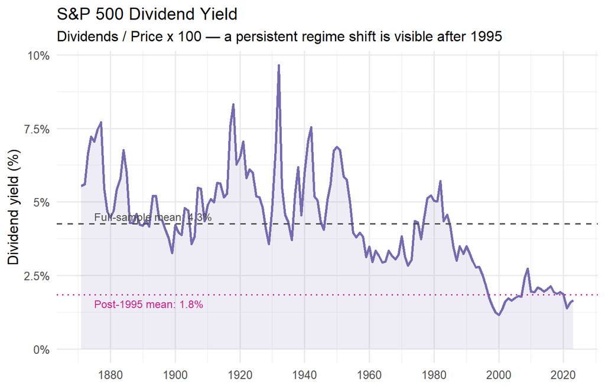

```r
mean_yield = mean(annual$div_yield, na.rm = TRUE)
recent_mean = mean(annual$div_yield[annual$year >= 1995], na.rm = TRUE)

ggplot(annual, aes(x = year, y = div_yield)) +
  geom_line(colour = "#756BB1", linewidth = 0.9) +
  geom_area(alpha = 0.12, fill = "#756BB1") +
  geom_hline(yintercept = mean_yield, linetype = "dashed",
             colour = "grey30", linewidth = 0.7) +
  annotate("text", x = 1875, y = mean_yield + 0.25,
           label = paste0("Full-sample mean: ", round(mean_yield, 1), "%"),
           size = 3.2, hjust = 0, colour = "grey30") +
  geom_hline(yintercept = recent_mean, linetype = "dotted",
             colour = "#D01C8B", linewidth = 0.7) +
  annotate("text", x = 1875, y = recent_mean - 0.3,
           label = paste0("Post-1995 mean: ", round(recent_mean, 1), "%"),
           size = 3.2, hjust = 0, colour = "#D01C8B") +
  scale_y_continuous(labels = function(x) paste0(x, "%")) +
  scale_x_continuous(breaks = seq(1880, 2030, 20)) +
  labs(
    title    = "S&P 500 Dividend Yield",
    subtitle = "Dividends / Price x 100 — a persistent regime shift is visible after 1995",
    x = NULL, y = "Dividend yield (%)"
  ) +
  theme_minimal(base_size = 12)
```

## Annual dividend growth rates

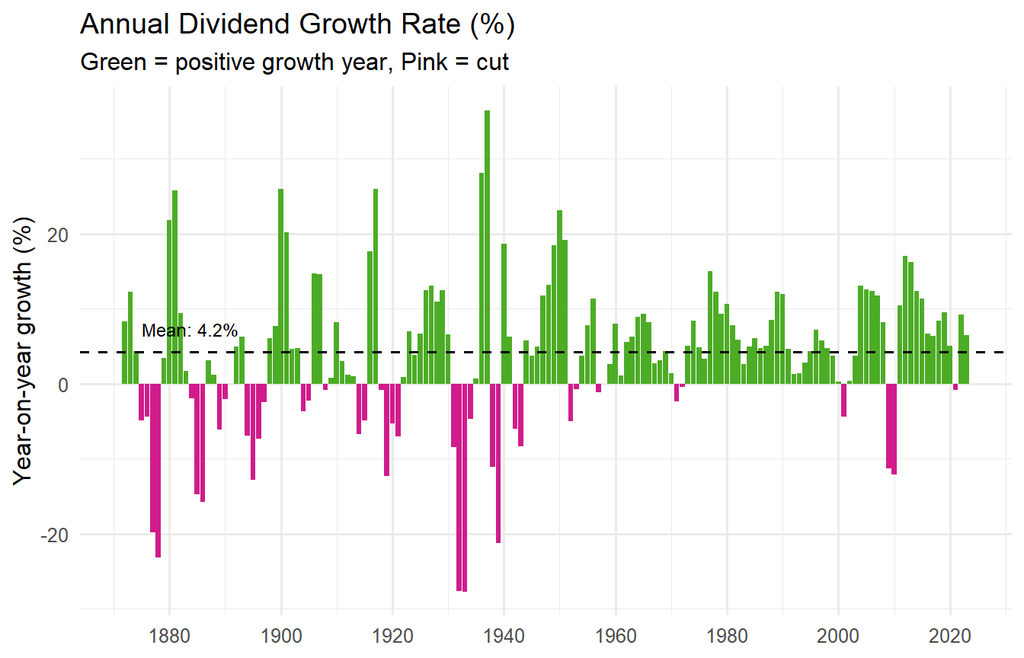

```r
growth_mean = mean(annual$div_growth, na.rm = TRUE)

annual %>%
  filter(!is.na(div_growth)) %>%
  ggplot(aes(x = year, y = div_growth, fill = div_growth > 0)) +
  geom_col(show.legend = FALSE) +
  geom_hline(yintercept = growth_mean, linetype = "dashed",
             colour = "black", linewidth = 0.7) +
  scale_fill_manual(values = c("TRUE" = "#4DAC26", "FALSE" = "#D01C8B")) +
  annotate("text", x = 1875, y = growth_mean + 3,
           label = paste0("Mean: ", round(growth_mean, 1), "%"),
           size = 3.2, hjust = 0) +
  scale_x_continuous(breaks = seq(1880, 2030, 20)) +
  labs(
    title    = "Annual Dividend Growth Rate (%)",
    subtitle = "Green = positive growth year, Pink = cut",
    x = NULL, y = "Year-on-year growth (%)"
  ) +
  theme_minimal(base_size = 12)
```

## Share of S&P 500 companies paying dividends

The dividend yield chart shows *how much* income the index pays — but that hides another fact: fewer companies paying dividends at all. The data below, sourced directly from S&P Dow Jones Indices, tracks the share of S&P 500 constituents paying a dividend each year since 1980.

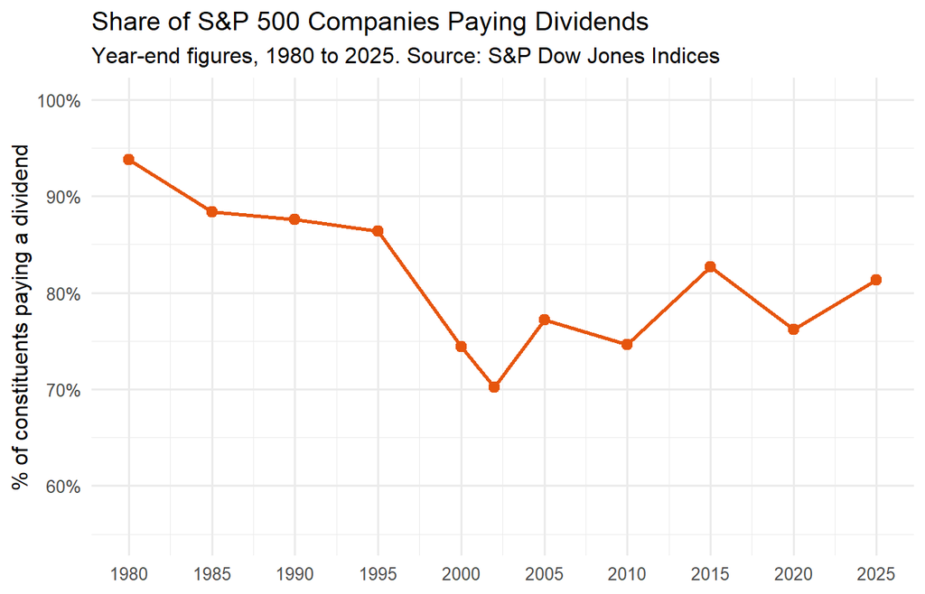

```r
# Source: S&P Dow Jones Indices - PAYERS sheet
payers = data.frame(
  year    = c(1980, 1985, 1990, 1995, 2000, 2002, 2005, 2010, 2015, 2020, 2025),
  pct_pay = c(93.8, 88.4, 87.6, 86.4, 74.4, 70.2, 77.2, 74.6, 82.7, 76.2, 81.3)
)

ggplot(payers, aes(x = year, y = pct_pay)) +
  geom_line(colour = "#E6550D", linewidth = 1) +
  geom_point(colour = "#E6550D", size = 2.5) +
  scale_y_continuous(limits = c(55, 100),
                     labels = function(x) paste0(x, "%")) +
  scale_x_continuous(breaks = seq(1980, 2025, 5)) +
  labs(
    title    = "Share of S&P 500 Companies Paying Dividends",
    subtitle = "Year-end figures, 1980 to 2025. Source: S&P Dow Jones Indices",
    x = NULL, y = "% of constituents paying a dividend"
  ) +
  theme_minimal(base_size = 12)
```

In 1980, **93.8% of S&P 500 companies** paid a dividend. That share declined steadily, hitting a low of around **70%** in 2001-2002 as the dot-com era brought a wave of non-paying tech companies into the index. Since then it has partially recovered, sitting at **81.3%** in 2025. The story is therefore more nuanced than a simple decline: the proportion of payers fell sharply into the early 2000s but has stabilised and even recovered since. This reinforces the dividend yield story — yields are low not just because prices rose, but because a meaningful portion of the index pays nothing at all.

## Summary statistics by era

```r
annual %>%
  mutate(Era = cut(year,
                   breaks = c(1870, 1919, 1944, 1969, 1989, 2009, 2019, Inf),
                   labels = c("1871-1919", "1920-1944", "1945-1969",
                              "1970-1989", "1990-2009", "2010-2019",
                              "2020-present (Post-Pandemic)"))) %>%
  group_by(Era) %>%
  summarise(
    `Avg Nominal Div ($)`  = round(mean(dividend, na.rm = TRUE), 2),
    `Avg Real Div ($)`     = round(mean(real_dividend, na.rm = TRUE), 2),
    `Avg Yield (%)`        = round(mean(div_yield, na.rm = TRUE), 2),
    `Avg Growth (%)`       = round(mean(div_growth, na.rm = TRUE), 2),
    .groups = "drop"
  )
```

```
## # A tibble: 7 × 5
##   Era                   `Avg Nominal Div ($)` `Avg Real Div ($)` `Avg Yield (%)`
##   <fct>                                 <dbl>              <dbl>           <dbl>
## 1 1871-1919                              0.32               10.5            5.18
## 2 1920-1944                              0.64               12.3            5.61
## 3 1945-1969                              1.79               18.8            4.25
## 4 1970-1989                              5.79               22.4            4.1
## 5 1990-2009                             17.2                30.1            2.12
## 6 2010-2019                             38.8                49.4            1.99
## 7 2020-present (Post-P…                 62.5                67.8            1.62
## # ℹ 1 more variable: `Avg Growth (%)` <dbl>
```

# Section 5: Time Series Analysis

## Trend: how fast have dividends grown?

We fit a line through log-dividends to estimate how fast dividends have grown per year on average (the CAGR).

```r
trend_model = lm(log_div ~ year, data = annual) # log div vs year
slope        = coef(trend_model)["year"]    # extract the slope
growth_factor = exp(slope)                  # convert from log-space
growth_rate  = growth_factor - 1            # decimal growth rate
cagr_nominal = growth_rate * 100            # change to percentage
cat(sprintf("Estimated nominal dividend CAGR (log-linear trend): %.2f%% per year\n", cagr_nominal))
```

```
## Estimated nominal dividend CAGR (log-linear trend): 3.88% per year
```

```r
# Real CAGR
trend_real = lm(log(real_dividend) ~ year, data = annual)
slope_real        = coef(trend_real)["year"]    # extract the slope
growth_factor_real = exp(slope_real)            # convert from log-space
growth_rate_real  = growth_factor_real - 1      # decimal growth rate
cagr_real         = growth_rate_real * 100      # as percentage

cat(sprintf("Estimated real dividend CAGR:                        %.2f%% per year\n", cagr_real))
```

```
## Estimated real dividend CAGR:                        1.20% per year
```

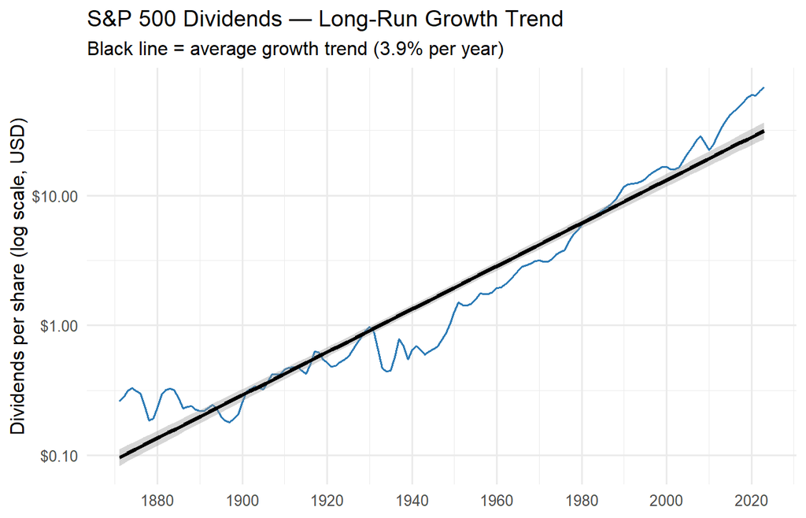

```r
annual %>%
  ggplot(aes(x = year, y = dividend)) +
  geom_line(colour = "#2C7BB6") +                          # actual dividend data (blue line)
  geom_smooth(method = "lm", formula = y ~ x,              # best-fit trend line (black)
              colour = "black", se = TRUE,
              aes(y = exp(log_div))) +
  scale_y_log10(labels = dollar_format()) +                 # log scale on y-axis
  scale_x_continuous(breaks = seq(1880, 2030, 20)) +        # tick marks every 20 years
  labs(
    title    = "S&P 500 Dividends — Long-Run Growth Trend",
    subtitle = paste0("Black line = average growth trend (",
                      round(cagr_nominal, 1), "% per year)"),
    x = NULL,
    y = "Dividends per share (log scale, USD)"
  ) +
  theme_minimal(base_size = 12)
```

## Stationarity

Before fitting an ARIMA model, we need to check if the data is stationary (i.e. fluctuates around a stable average). If not, we need to convert it to growth rates first.

```r
log_div_clean = annual$log_div[!is.na(annual$log_div)]        # keep only non-NA log-dividend values
start_year    = min(annual$year[!is.na(annual$log_div)])       # find the earliest year with valid data
ts_log_div    = ts(log_div_clean, start = start_year)          # Turn it into a time series so R treats it as yearly data in order

# Checking if series is stationary
adf_levels = adf.test(ts_log_div) # ADF test on levels
adf_diff   = adf.test(diff(ts_log_div)) # ADF test on differences - meaning year-to-year changes are stationary

cat("ADF test on log-dividend levels:\n")
```

```
## ADF test on log-dividend levels:
```

```r
cat(sprintf("  Statistic: %.4f  |  p-value: %.4f\n", adf_levels$statistic, adf_levels$p.value))
```

```
##   Statistic: -2.0561  |  p-value: 0.5530
```

```r
cat(ifelse(adf_levels$p.value > 0.05,
           "  => Fail to reject unit root. Series is NON-STATIONARY.\n\n",
           "  => Reject unit root. Series is stationary.\n\n"))
```

```
##   => Fail to reject unit root. Series is NON-STATIONARY.
```

```r
cat("ADF test on first-differenced log-dividends (= growth rates):\n")
```

```
## ADF test on first-differenced log-dividends (= growth rates):
```

```r
cat(sprintf("  Statistic: %.4f  |  p-value: %.4f\n", adf_diff$statistic, adf_diff$p.value))
```

```
##   Statistic: -6.1716  |  p-value: 0.0100
```

```r
cat(ifelse(adf_diff$p.value < 0.05,
           "  => Reject unit root. Growth rates ARE stationary. Series is I(1).\n",
           "  => Fail to reject unit root.\n"))
```

```
##   => Reject unit root. Growth rates ARE stationary. Series is I(1).
```

**Interpretation:** Dividends keep rising over time with no fixed average — the ADF test confirms this (non-stationary). But when we look at the yearly growth rates instead, they do fluctuate around a stable average (stationary). So we need to convert the data into growth rates first — that’s what allows the ARIMA model to work properly.

## Seasonal decomposition (STL)

Using monthly data, we split the dividend series into three parts: the long-run trend, a seasonal pattern, and leftover noise.

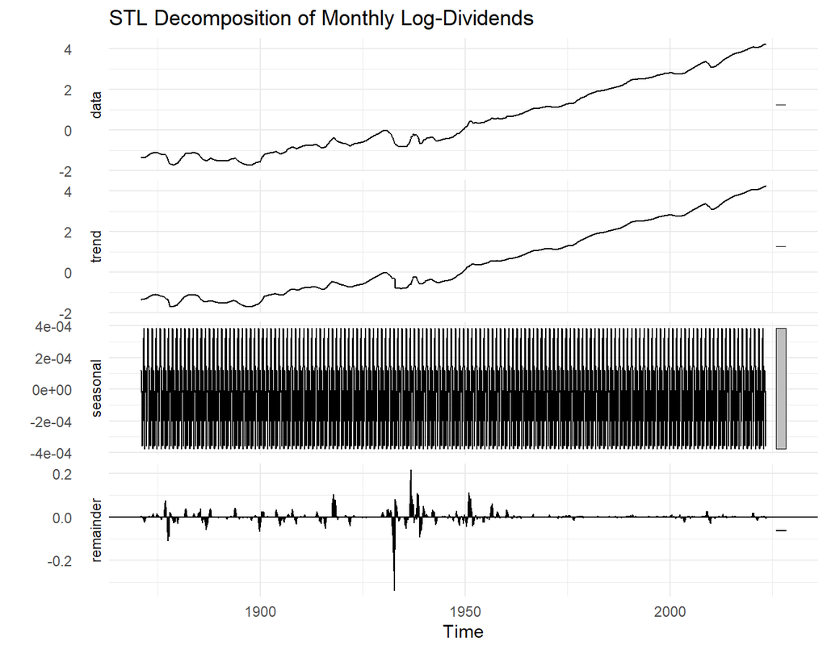

```r
ts_monthly = ts(
  df$dividend,
  start     = c(year(min(df$date)), month(min(df$date))),
  frequency = 12
)

stl_fit = stl(log(ts_monthly), s.window = "periodic", robust = TRUE)
autoplot(stl_fit) +
  labs(title = "STL Decomposition of Monthly Log-Dividends") +
  theme_minimal(base_size = 11)
```

## ARIMA model

We fit an ARIMA model to forecast future dividends. Since dividends trend upward (non-stationary), we first convert them to growth rates (one round of differencing) so the model can work with stable data.

```r
arima_fit = auto.arima(
  ts_log_div,
  d             = 1,
  stepwise      = FALSE,
  approximation = FALSE,
  ic            = "aicc"
)

summary(arima_fit)
```

```
## Series: ts_log_div
## ARIMA(4,1,0) with drift
##
## Coefficients:
##          ar1      ar2     ar3      ar4   drift
##       0.8344  -0.6925  0.3637  -0.2996  0.0362
## s.e.  0.0772   0.0988  0.0987   0.0770  0.0074
##
## sigma^2 = 0.005378:  log likelihood = 183.42
## AIC=-354.84   AICc=-354.26   BIC=-336.7
##
## Training set error measures:
##                        ME       RMSE        MAE      MPE     MAPE      MASE
## Training set 3.439204e-05 0.07187983 0.05264086 4.179605 10.45397 0.6396275
##                    ACF1
## Training set 0.01766597
```

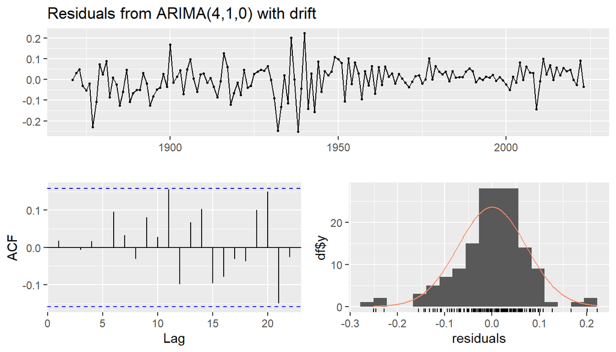

```
##
##  Ljung-Box test
##
## data:  Residuals from ARIMA(4,1,0) with drift
## Q* = 3.0991, df = 6, p-value = 0.7963
##
## Model df: 4.   Total lags used: 10
```

```r
checkresiduals(arima_fit)
```

```r
lb = Box.test(residuals(arima_fit), lag = 10, type = "Ljung-Box")
cat(sprintf("Ljung-Box test (lag 10): p-value = %.4f\n", lb$p.value))
```

```
## Ljung-Box test (lag 10): p-value = 0.9790
```

```r
cat(ifelse(lb$p.value > 0.05,
           "Residuals look like white noise. Model is adequate.\n",
           "Some residual autocorrelation remains.\n"))
```

```
## Residuals look like white noise. Model is adequate.
```

## Dividend forecast (10 years)

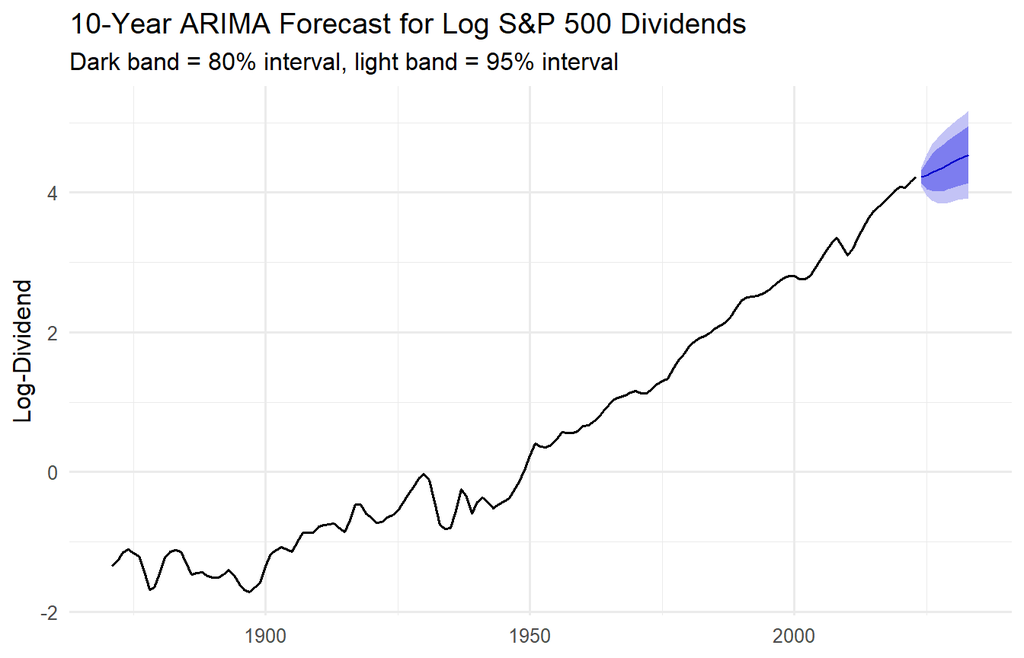

```r
fc = forecast(arima_fit, h = 10)

autoplot(fc) +
  labs(
    title    = "10-Year ARIMA Forecast for Log S&P 500 Dividends",
    subtitle = "Dark band = 80% interval, light band = 95% interval",
    x        = NULL,
    y        = "Log-Dividend"
  ) +
  theme_minimal(base_size = 12)
```

```r
fc_df = as.data.frame(fc)
fc_df$Year           = seq(max(annual$year) + 1, by = 1, length.out = 10)
fc_df$Forecast       = round(exp(fc_df[["Point Forecast"]]), 2)
fc_df$Lower_80       = round(exp(fc_df[["Lo 80"]]), 2)
fc_df$Upper_80       = round(exp(fc_df[["Hi 80"]]), 2)
fc_df$Lower_95       = round(exp(fc_df[["Lo 95"]]), 2)
fc_df$Upper_95       = round(exp(fc_df[["Hi 95"]]), 2)
fc_df[, c("Year","Forecast","Lower_80","Upper_80","Lower_95","Upper_95")]
```

```
##      Year Forecast Lower_80 Upper_80 Lower_95 Upper_95
## 2024 2024    68.32    62.19    75.05    59.17    78.88
## 2025 2025    69.82    57.37    84.97    51.71    94.28
## 2026 2026    72.80    56.05    94.56    48.80   108.59
## 2027 2027    75.06    55.44   101.61    47.23   119.29
## 2028 2028    77.54    55.62   108.10    46.65   128.89
## 2029 2029    80.99    57.02   115.04    47.35   138.53
## 2030 2030    84.38    58.62   121.47    48.34   147.31
## 2031 2031    87.45    59.92   127.62    49.05   155.90
## 2032 2032    90.66    61.14   134.44    49.63   165.61
## 2033 2033    94.00    62.30   141.82    50.11   176.32
```

The prediction intervals get wider over time because long-run forecasts are naturally uncertain. The central forecast simply assumes dividends keep growing at the same historical rate — it’s a reasonable baseline, not an exact prediction.

## Forecast vs Actual Comparison

Since the Shiller dataset ends in 2023, we can validate the ARIMA forecast against actual 2024 and 2025 dividend data for the S&P 500.

```r
# Actual S&P 500 data
actuals = data.frame(
  Year       = c(2024, 2025),
  Actual_Div = c(74.83, 79.52)
)

# Extract ARIMA forecast for same years
fc_compare = fc_df[fc_df$Year %in% c(2024, 2025), c("Year", "Forecast", "Lower_95", "Upper_95")]
colnames(fc_compare) = c("Year", "Forecast_Div", "Lo_95", "Hi_95")

# Merge and calculate error
comparison = merge(fc_compare, actuals, by = "Year")
comparison$Error_Pct   = round((comparison$Forecast_Div / comparison$Actual_Div - 1) * 100, 2)
comparison$Within_95CI = comparison$Actual_Div >= comparison$Lo_95 & comparison$Actual_Div <= comparison$Hi_95
comparison
```

```
##   Year Forecast_Div Lo_95 Hi_95 Actual_Div Error_Pct Within_95CI
## 1 2024        68.32 59.17 78.88      74.83      -8.7        TRUE
## 2 2025        69.82 51.71 94.28      79.52     -12.2        TRUE
```

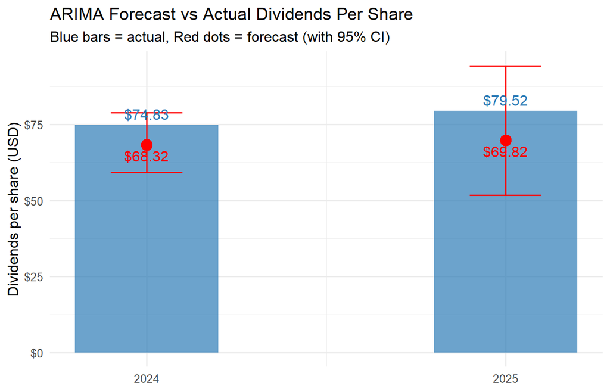

```r
ggplot(comparison, aes(x = Year)) +
  geom_col(aes(y = Actual_Div), fill = "#2C7BB6", alpha = 0.7, width = 0.4) +
  geom_point(aes(y = Forecast_Div), colour = "red", size = 4) +
  geom_errorbar(aes(ymin = Lo_95, ymax = Hi_95), width = 0.2, colour = "red") +
  geom_text(aes(y = Actual_Div, label = paste0("$", Actual_Div)),
            vjust = -0.5, colour = "#2C7BB6") +
  geom_text(aes(y = Forecast_Div, label = paste0("$", Forecast_Div)),
            vjust = 1.5, colour = "red") +
  scale_x_continuous(breaks = c(2024, 2025)) +
  scale_y_continuous(labels = dollar_format()) +
  labs(
    title    = "ARIMA Forecast vs Actual Dividends Per Share",
    subtitle = "Blue bars = actual, Red dots = forecast (with 95% CI)",
    x = NULL, y = "Dividends per share (USD)"
  ) +
  theme_minimal(base_size = 12)
```

Actual S&P 500 dividends per share were $74.83 in 2024 (+6.4% YoY) and $79.52 in 2025 (+6.3% YoY), sourced from S&P Dow Jones Indices. The table above shows the forecast error and whether the actuals fell within the model’s 95% confidence interval, demonstrating how close the ARIMA forecast got.